# Análisis Estadístico Descriptivo e Inferencial del Impacto de Condiciones Climáticas y Prácticas Agrícolas sobre el Calibre de las Paltas Hass

Grupo Nº4 - Fernandez D. Abel, Fernandez D. Rody, Márquez M. Andre, Yactayo C. David

23 de abril de 2024

# 1. Introducción

## 1.1. Contexto del Proyecto

El cultivo de la palta Hass se ha convertido en un pilar económico para las regiones agrícolas que disfrutan del clima y suelo propicio para su desarrollo. Con su creciente demanda a nivel global, el análisis detallado de los patrones de producción y calidad del fruto se hace indispensable en cualquier empresa agrícola dedicada a esta actividad. Este proyecto busca examinar el perfil de calibre de las paltas Hass a lo largo de cuatro semanas críticas de cosecha en una empresa agrícola peruana para identificar tendencias y correlaciones que puedan influir en su producción.

## 1.2. Importancia del Análisis de Calibres en la Producción de Paltas

El análisis de los calibres de paltas Hass es crucial para maximizar la rentabilidad y satisfacer los estándares del mercado. Un calibre uniforme es a menudo un indicador de calidad y homogeneidad del producto, factores que pueden afectar el precio y la preferencia del consumidor. Comprender cómo fluctúan los calibres en respuesta a variables ambientales y prácticas agrícolas puede conducir a una mejor gestión de los recursos y optimización de los procesos de cultivo y post-cosecha.

# 2. Planteamiento del Problema

## 2.1. Descripción del Problema

La producción de palta Hass enfrenta la complejidad de mantener la calidad frente a la variabilidad de factores ambientales y agronómicos. La heterogeneidad en los calibres de las paltas Hass afecta directamente la cadena de valor, desde la gestión de cultivos hasta la satisfacción del consumidor final. Identificar y comprender las variables que más influyen en la calidad y uniformidad del calibre de las paltas se convierte, por tanto, en una prioridad para optimizar la producción.¿Cómo podemos analizar los patrones temporales y de calibre en la producción de paltas Hass a lo largo de un periodo de cuatro semanas para desarrollar recomendaciones que mejoren la gestión agrícola y se adapten eficazmente a las condiciones estacionales y prácticas de cultivo?

## 2.2. Objetivos del Proyecto

### 2.2.1. Objetivo General

Analizar los patrones de calibre y producción temporal de las paltas Hass a lo largo de cuatro semanas críticas de cosecha para desarrollar un conjunto de recomendaciones dirigidas a optimizar la gestión agrícola y la adaptación a las variables estacionales y las prácticas de cultivo.

### 2.2.2. Objetivos Específicos

- Investigar cómo los calibres de las paltas Hass varían en un marco temporal semanal y determinar si estos cambios están correlacionados con prácticas agrícolas específicas o con condiciones ambientales que se presentan durante las cuatro semanas.
- Analizar los datos de producción para determinar la existencia de tendencias o patrones en la producción y los calibres que puedan ser atribuidos a variaciones climáticas o a la aplicación de tratamientos específicos durante el periodo estudiado.
- Formular recomendaciones preliminares basadas en los resultados del análisis que puedan ser aplicadas en el corto plazo para ajustar y mejorar las prácticas de cultivo en respuesta a las observaciones de las condiciones y tratamientos de las semanas analizadas.

# 3. Metodología

## 3.1. Descripción de los Datos

Se utilizarán dos conjuntos de datos que contienen registros semanalizados de calibres de paltas Hass y reportes detallados de las condiciones de cultivo, incluyendo datos climáticos y de tratamientos aplicados.

### 3.1.1. Diccionario de datos para el dataset ‘calibres’

| Variable | Descripción |
| --- | --- |
| semana | Número de semana del año en la que se registraron los datos. |
| mes | Mes en el que se registraron los datos. |
| variedad_producto | Tipo de palta haas. |
| color_producto | Color del producto registrado. |
| calibre | Tamaño del calibre del producto. |
| kg_calibre | Peso en kilogramos asociado al calibre del producto. |
| porcentaje_calibre_por_guia_remision | Porcentaje del calibre específico por guía de remisión. |
| guia_remision | Número de la guía de remisión. |
| reporte_produccion | Identificador del reporte de producción. |
| fecha | Fecha en la que se registró el dato. |
| cliente | Identificador del cliente que recibió el lote. |

### 3.1.2. Diccionario de datos para el dataset ‘reportes’

| Variable | Descripción |
| --- | --- |
| semana | Número de semana del año cuando se registraron los datos. |
| mes | Mes cuando se registraron los datos. |
| fundo | Identificador del fundo donde se producen las paltas. |
| empresa | Nombre de la empresa propietaria del fundo. |
| lote | Número o identificación del lote dentro del fundo. |
| hectareas | Área en hectáreas donde se cultivan las paltas. |
| variedad_producto | Variedad de la palta cultivada. |
| color_producto | Color de la palta registrada. |
| guia_remision | Número de la guía de remisión asociada a la producción. |
| reporte_produccion | Identificador del reporte de producción. |
| fecha | Fecha en que se registró el dato. |
| total_jabas | Cantidad total de cajas recolectadas. |
| peso_promedio_jaba | Peso promedio por caja de palta. |
| cajas_exportadas_10kg | Número de cajas de 10kg exportadas. |
| ingreso_packing_kg_bruto | Peso bruto total ingresado al packing. |
| kg_exportados | Kilogramos totales exportados. |
| porcentaje_exportados | Porcentaje de la producción exportada. |
| kg_descarte | Kilogramos totales descartados. |
| porcentaje_descarte | Porcentaje de la producción descartada. |
| kg_merma | Kilogramos de merma en la producción. |
| porcentaje_merma | Porcentaje de merma en la producción. |
| kg_descarte_campo | Kilogramos de producto descartado en campo. |
| kg_brutos_lote | Peso bruto por lote de producción. |
| kg_brutos_hectarea | Peso bruto por hectárea. |
| kg_exportados_hectarea | Kilogramos exportados por hectárea. |
| estado | Estado del lote o producción. |
| cliente | Identificador del cliente que recibe la producción. |
| temperatura_promedio | Temperatura promedio durante la semana de reporte. |
| temperatura_maxima | Temperatura máxima alcanzada durante la semana de reporte. |
| temperatura_minima | Temperatura mínima registrada durante la semana de reporte. |
| humedad_promedio | Humedad promedio durante la semana de reporte. |
| humedad_maxima | Humedad máxima alcanzada durante la semana de reporte. |
| humedad_minima | Humedad mínima registrada durante la semana de reporte. |
| evapotranspiracion_acumulada | Total de evapotranspiración acumulada durante la semana. |
| insumo_para_tratamiento | Insumo utilizado para el tratamiento de las paltas. |
| naturaleza_del_insumo | Clasificación del insumo utilizado (mineral, orgánica, química). |
| dosis_litros_por_hectarea | Cantidad de insumo utilizado por hectárea expresada en litros. |
| tipo_insumo | Clasificación del insumo utilizado según su propósito. |

# 4. Análisis Exploratorio de Datos (EDA)

## 4.1. Carga y Limpieza de Datos

### 4.1.1. Carga de datos

```r
# Configuración del directorio de trabajo
setwd("D:/PAC")

# Cargar los datasets
calibres <- read.csv("calibres.csv", sep = ";",  stringsAsFactors = FALSE)
reporte <- read.csv("reporte.csv", sep = ";",  stringsAsFactors = FALSE)

# Mostrar las primeras filas de cada dataset
head(calibres)
```

```
##   semana   mes variedad_producto color_producto calibre kg_calibre
## 1     13 Marzo              Hass          Negra      08         60
## 2     13 Marzo              Hass          Negra      10       2160
## 3     13 Marzo              Hass          Negra      12       9640
## 4     13 Marzo              Hass          Negra      14      10250
## 5     13 Marzo              Hass          Negra      16       1890
## 6     13 Marzo              Hass          Negra      20         30
##   porcentaje_calibre_por_guia_remision   guia_remision reporte_produccion
## 1                               0.0025 T008 N° 0000109       0001-0002239
## 2                               0.0898 T008 N° 0000109       0001-0002239
## 3                               0.4007 T008 N° 0000109       0001-0002239
## 4                               0.4260 T008 N° 0000109       0001-0002239
## 5                               0.0786 T008 N° 0000109       0001-0002239
## 6                               0.0012 T008 N° 0000109       0001-0002239
##        fecha  cliente
## 1 25/03/2024 CLIENTE2
## 2 25/03/2024 CLIENTE2
## 3 25/03/2024 CLIENTE2
## 4 25/03/2024 CLIENTE2
## 5 25/03/2024 CLIENTE2
## 6 25/03/2024 CLIENTE2
```

```r
head(reporte)
```

```
##   semana   mes  fundo empresa   lote hectareas variedad_producto color_producto
## 1     13 Marzo FUNDO1 EMPRESA DNH-06      9.75              Hass          Negra
## 2     13 Marzo FUNDO1 EMPRESA DNH-05     10.91              Hass          Negra
## 3     13 Marzo FUNDO1 EMPRESA DNH-04     11.76              Hass          Negra
## 4     13 Marzo FUNDO1 EMPRESA DNH-03     11.62              Hass          Negra
## 5     13 Marzo FUNDO1 EMPRESA DNH-02     11.50              Hass          Negra
## 6     13 Marzo FUNDO2 EMPRESA CVH-17      7.21              Hass          Negra
##     guia_remision reporte_produccion      fecha total_jabas peso_promedio_jaba
## 1 T008 N° 0000109       0001-0002239 25/03/2024           5             428.13
## 2 T008 N° 0000109       0001-0002239 25/03/2024          10             428.13
## 3 T008 N° 0000109       0001-0002239 25/03/2024          18             428.13
## 4 T008 N° 0000109       0001-0002239 25/03/2024          19             428.13
## 5 T008 N° 0000109       0001-0002239 25/03/2024           5             428.13
## 6 T008 N° 0000109       0001-0002239 25/03/2024           3             428.13
##   cajas_exportadas_10kg ingreso_packing_kg_bruto kg_exportados
```

[output cut: 48 more lines]

### 4.1.2. Limpieza inicial

Manejo de valores faltantes, corrección de tipos de datos

#### 4.1.2.1. Inspección inicial de los datos

**Inspección inicial de datos del dataset ‘calibres’**

```r
# Información general del dataset 'calibres'
str(calibres)
```

```
## 'data.frame':    260 obs. of  11 variables:
##  $ semana                              : int  13 13 13 13 13 13 13 13 13 13 ...
##  $ mes                                 : chr  "Marzo" "Marzo" "Marzo" "Marzo" ...
##  $ variedad_producto                   : chr  "Hass" "Hass" "Hass" "Hass" ...
##  $ color_producto                      : chr  "Negra" "Negra" "Negra" "Negra" ...
##  $ calibre                             : chr  "08" "10" "12" "14" ...
##  $ kg_calibre                          : num  60 2160 9640 10250 1890 ...
##  $ porcentaje_calibre_por_guia_remision: num  0.0025 0.0898 0.4007 0.426 0.0786 ...
##  $ guia_remision                       : chr  "T008 N° 0000109" "T008 N° 0000109" "T008 N° 0000109" "T008 N° 0000109" ...
##  $ reporte_produccion                  : chr  "0001-0002239" "0001-0002239" "0001-0002239" "0001-0002239" ...
##  $ fecha                               : chr  "25/03/2024" "25/03/2024" "25/03/2024" "25/03/2024" ...
##  $ cliente                             : chr  "CLIENTE2" "CLIENTE2" "CLIENTE2" "CLIENTE2" ...
```

**Inspección inicial de datos del dataset ‘reporte’**

```r
# Información general del dataset 'reporte'
str(reporte)
```

```
## 'data.frame':    121 obs. of  38 variables:
##  $ semana                      : int  13 13 13 13 13 13 13 13 13 13 ...
##  $ mes                         : chr  "Marzo" "Marzo" "Marzo" "Marzo" ...
##  $ fundo                       : chr  "FUNDO1" "FUNDO1" "FUNDO1" "FUNDO1" ...
##  $ empresa                     : chr  "EMPRESA" "EMPRESA" "EMPRESA" "EMPRESA" ...
##  $ lote                        : chr  "DNH-06" "DNH-05" "DNH-04" "DNH-03" ...
##  $ hectareas                   : num  9.75 10.91 11.76 11.62 11.5 ...
##  $ variedad_producto           : chr  "Hass" "Hass" "Hass" "Hass" ...
##  $ color_producto              : chr  "Negra" "Negra" "Negra" "Negra" ...
##  $ guia_remision               : chr  "T008 N° 0000109" "T008 N° 0000109" "T008 N° 0000109" "T008 N° 0000109" ...
##  $ reporte_produccion          : chr  "0001-0002239" "0001-0002239" "0001-0002239" "0001-0002239" ...
##  $ fecha                       : chr  "25/03/2024" "25/03/2024" "25/03/2024" "25/03/2024" ...
##  $ total_jabas                 : int  5 10 18 19 5 3 7 1 6 5 ...
##  $ peso_promedio_jaba          : num  428 428 428 428 428 ...
##  $ cajas_exportadas_10kg       : num  200 401 722 762 200 ...
```

[output cut: 24 more lines]

#### 4.1.2.2. Limpieza inicial de datos

**Identificación de valores faltantes**

```r
sum(is.na(calibres))
```

```
## [1] 0
```

```r
sum(is.na(reporte))
```

```
## [1] 0
```

No se encontraron valores nulos en los datasets.

## 4.2. Análisis Descriptivo General

### 4.2.1. Resumen estadístico por dataset

**Dimensiones y resumen estadístico dataset ‘calibres’**

```r
# Dimensiones de 'calibres'
dim(calibres)
```

```
## [1] 260  11
```

```r
# Resumen estadístico básico
summary(calibres)
```

```
##      semana          mes            variedad_producto  color_producto
##  Min.   :13.00   Length:260         Length:260         Length:260
##  1st Qu.:14.00   Class :character   Class :character   Class :character
##  Median :15.00   Mode  :character   Mode  :character   Mode  :character
##  Mean   :14.76
##  3rd Qu.:15.00
##  Max.   :16.00
##    calibre            kg_calibre      porcentaje_calibre_por_guia_remision
##  Length:260         Min.   :   10.0   Min.   :0.00020
##  Class :character   1st Qu.:  517.5   1st Qu.:0.02562
##  Mode  :character   Median : 1495.0   Median :0.09285
##                     Mean   : 2707.3   Mean   :0.14615
##                     3rd Qu.: 3872.5   3rd Qu.:0.17300
##                     Max.   :17680.0   Max.   :1.00000
##  guia_remision      reporte_produccion    fecha             cliente
##  Length:260         Length:260         Length:260         Length:260
##  Class :character   Class :character   Class :character   Class :character
##  Mode  :character   Mode  :character   Mode  :character   Mode  :character
##
##
##
```

**Dimensiones y resumen estadístico dataset ‘reporte’**

```r
# Dimensiones de 'reporte'
dim(reporte)
```

```
## [1] 121  38
```

```r
# Resumen estadístico básico
summary(reporte)
```

```
##      semana          mes               fundo             empresa
##  Min.   :13.00   Length:121         Length:121         Length:121
##  1st Qu.:13.00   Class :character   Class :character   Class :character
##  Median :14.00   Mode  :character   Mode  :character   Mode  :character
##  Mean   :14.38
##  3rd Qu.:15.00
##  Max.   :16.00
##      lote             hectareas     variedad_producto  color_producto
##  Length:121         Min.   : 6.55   Length:121         Length:121
##  Class :character   1st Qu.:10.24   Class :character   Class :character
##  Mode  :character   Median :11.76   Mode  :character   Mode  :character
##                     Mean   :14.22
##                     3rd Qu.:17.18
##                     Max.   :26.57
##  guia_remision      reporte_produccion    fecha            total_jabas
##  Length:121         Length:121         Length:121         Min.   : 1.00
##  Class :character   Class :character   Class :character   1st Qu.: 2.00
##  Mode  :character   Mode  :character   Mode  :character   Median : 5.00
##                                                           Mean   :14.83
##                                                           3rd Qu.:21.00
##                                                           Max.   :60.00
##  peso_promedio_jaba cajas_exportadas_10kg ingreso_packing_kg_bruto
##  Min.   :  0.0      Min.   :   0.00       Min.   :    0.0
##  1st Qu.:416.2      1st Qu.:  80.77       1st Qu.:  840.2
##  Median :426.7      Median : 204.62       Median : 2169.6
##  Mean   :402.0      Mean   : 580.69       Mean   : 6291.2
##  3rd Qu.:439.0      3rd Qu.: 858.19       3rd Qu.: 9175.9
##  Max.   :679.5      Max.   :2448.89       Max.   :27291.0
##  kg_exportados     porcentaje_exportados  kg_descarte      porcentaje_descarte
##  Min.   :    0.0   Min.   :0.0000        Min.   :   0.00   Min.   :0.00000
##  1st Qu.:  807.7   1st Qu.:0.9178        1st Qu.:   0.00   1st Qu.:0.00000
##  Median : 2046.2   Median :0.9431        Median :  33.16   Median :0.01590
##  Mean   : 5806.9   Mean   :0.9004        Mean   : 265.68   Mean   :0.02325
##  3rd Qu.: 8581.9   3rd Qu.:0.9618        3rd Qu.: 267.62   3rd Qu.:0.02920
##  Max.   :24488.9   Max.   :1.0000        Max.   :2736.90   Max.   :0.10030
##     kg_merma      porcentaje_merma  kg_descarte_campo kg_brutos_lote
##  Min.   :  0.00   Min.   :0.00000   Min.   :  0.00    Min.   :   50.0
##  1st Qu.:  0.00   1st Qu.:0.00000   1st Qu.:  0.00    1st Qu.:  840.2
##  Median : 84.29   Median :0.03500   Median :  0.00    Median : 2169.6
##  Mean   :218.54   Mean   :0.02671   Mean   : 22.12    Mean   : 6313.3
```

[output cut: 22 more lines]

```
##  Max.   :80.85    Max.   :94.00   Max.   :62.00   Max.   :6.240
##  insumo_para_tratamiento naturaleza_del_insumo dosis_litros_por_hectarea
##  Length:121              Length:121            Min.   :1.000
##  Class :character        Class :character      1st Qu.:1.000
##  Mode  :character        Mode  :character      Median :2.000
##                                                Mean   :1.986
##                                                3rd Qu.:2.500
##                                                Max.   :4.000
##  tipo_insumo
##  Length:121
##  Class :character
##  Mode  :character
##
##
##
```

### 4.2.2. Visualización de distribuciones numéricas

##### 4.2.2.1.1. Variable kg_calibre

Se obtienen los datos descriptivos más reperesentativos de la variable.

```r
# Datos descriptivos de la variable
summary(calibres$kg_calibre)
```

```
##    Min. 1st Qu.  Median    Mean 3rd Qu.    Max.
##    10.0   517.5  1495.0  2707.3  3872.5 17680.0
```

Se continua con la generación de gráficos.

[figure not shown]

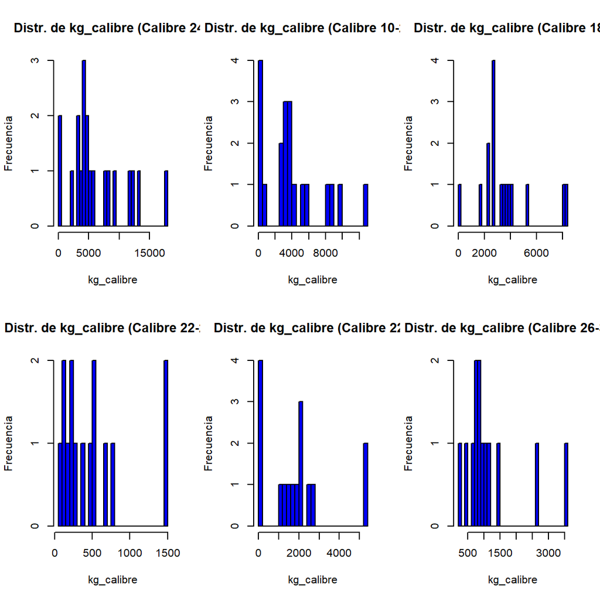

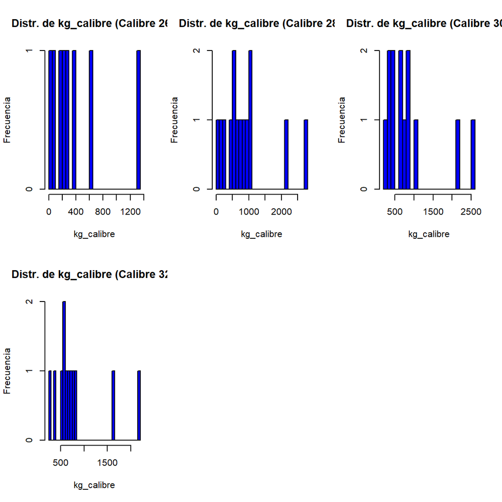

```r
# Histograma para la variable numérica kg_calibre
calibres_por_calibre <- split(calibres$kg_calibre, calibres$calibre)

par(mfrow=c(2, 3))

for (i in 1:length(calibres_por_calibre)) {
  hist(calibres_por_calibre[[i]], main=paste("Distr. de kg_calibre (Calibre", unique(calibres$calibre)[i], ")"),
       xlab="kg_calibre", ylab="Frecuencia", col="blue", breaks=30)
}
```

##### 4.2.2.1.2. Variable porcentaje_calibre_por_guia_remision

Se obtienen los datos descriptivos más reperesentativos de la variable.

```r
# Datos descriptivos de la variable
summary(calibres$porcentaje_calibre_por_guia_remision)
```

```
##    Min. 1st Qu.  Median    Mean 3rd Qu.    Max.
## 0.00020 0.02562 0.09285 0.14615 0.17300 1.00000
```

Se continua con la generación de gráficos.

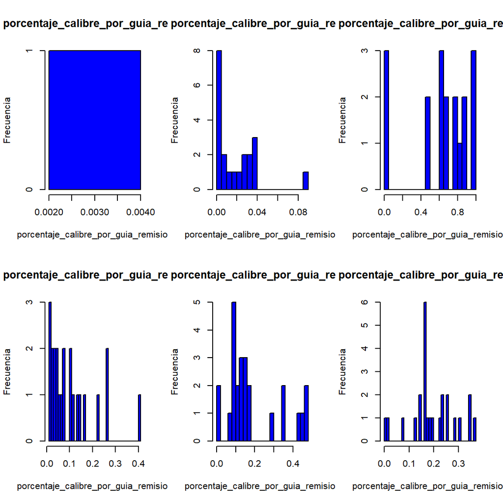

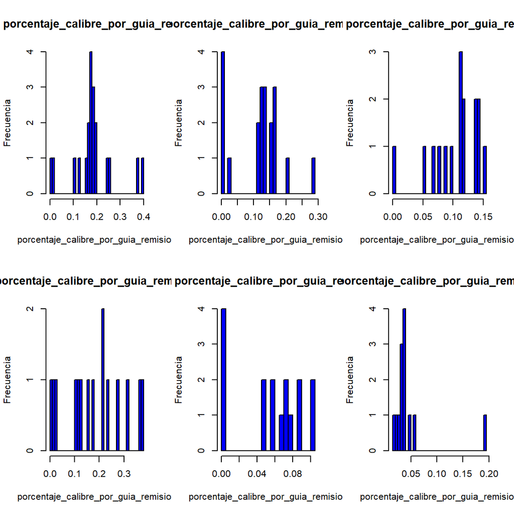

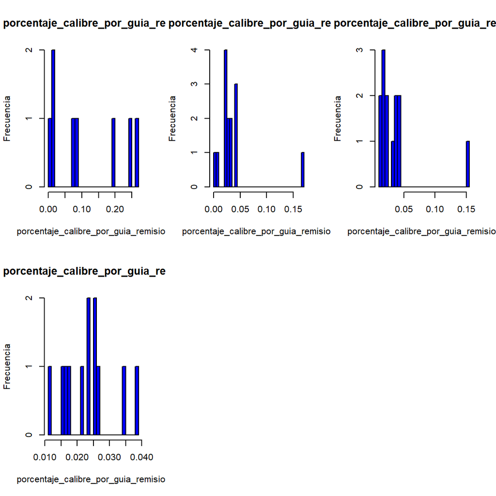

```r
# Histograma para la variable numérica porcentaje_calibre_por_guia_remision
calibres_por_calibre <- split(calibres$porcentaje_calibre_por_guia_remision, calibres$calibre)

par(mfrow=c(2, 3))

for (i in 1:length(calibres_por_calibre)) {
  hist(calibres_por_calibre[[i]], main=paste("Distribución de porcentaje_calibre_por_guia_remision (Calibre", unique(calibres$calibre)[i], ")"),
       xlab="porcentaje_calibre_por_guia_remision", ylab="Frecuencia", col="blue", breaks=30)
}
```

#### 4.2.2.2. Histogramas y Boxplots para las variables numéricas más relevantes del dataset Reporte

##### 4.2.2.2.1. Variable hectareas

Se obtienen los datos descriptivos más reperesentativos de la variable.

```r
# Datos descriptivos de la variable
summary(reporte$hectareas)
```

```
##    Min. 1st Qu.  Median    Mean 3rd Qu.    Max.
##    6.55   10.24   11.76   14.22   17.18   26.57
```

Se continua con la generación de gráficos.

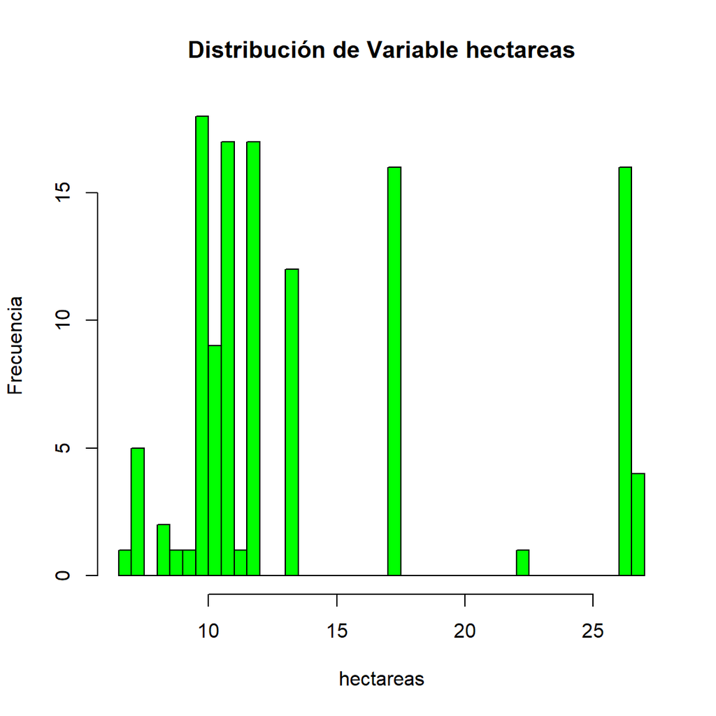

```r
# Histograma para la variable numérica hectareas
hist(reporte$hectareas, main="Distribución de Variable hectareas", xlab="hectareas", ylab="Frecuencia", col="green", breaks=30)
```

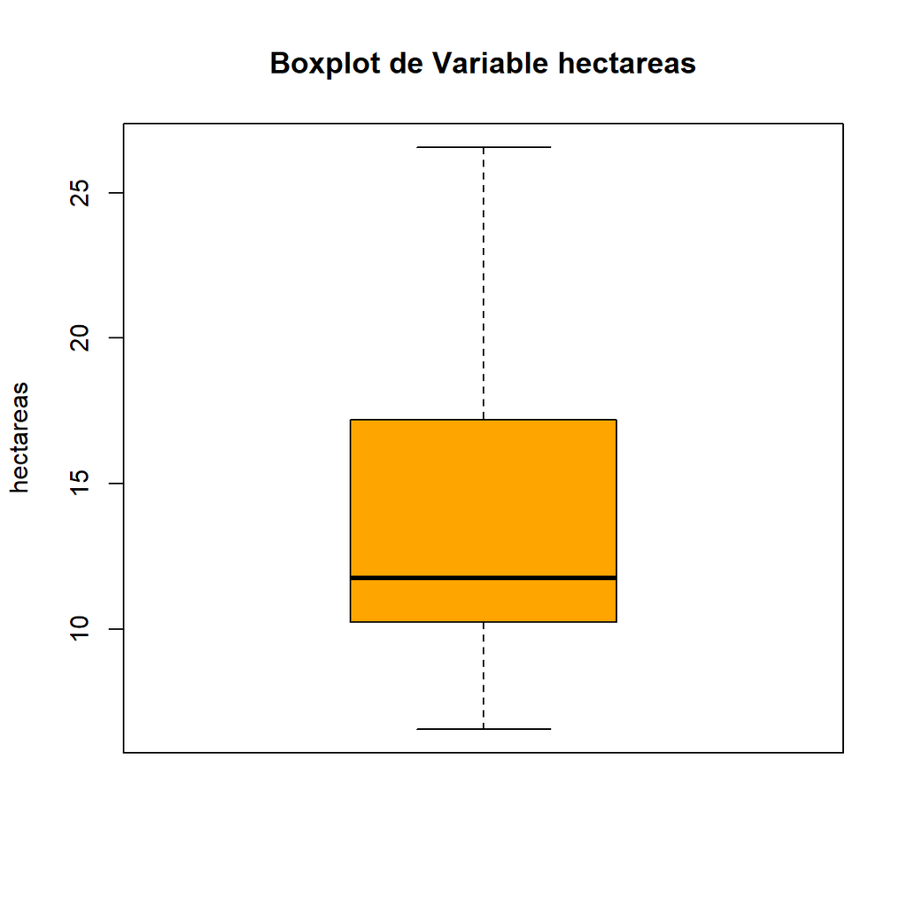

```r
# Boxplot para la variable numérica hectareas
boxplot(reporte$hectareas, main="Boxplot de Variable hectareas", ylab="hectareas", col="orange")
```

##### 4.2.2.2.2. Variable kg_brutos_lote

Se obtienen los datos descriptivos más reperesentativos de la variable.

```r
# Datos descriptivos de la variable
summary(reporte$kg_brutos_lote)
```

```
##    Min. 1st Qu.  Median    Mean 3rd Qu.    Max.
##    50.0   840.2  2169.6  6313.3  9175.9 27291.0
```

Se continua con la generación de gráficos.

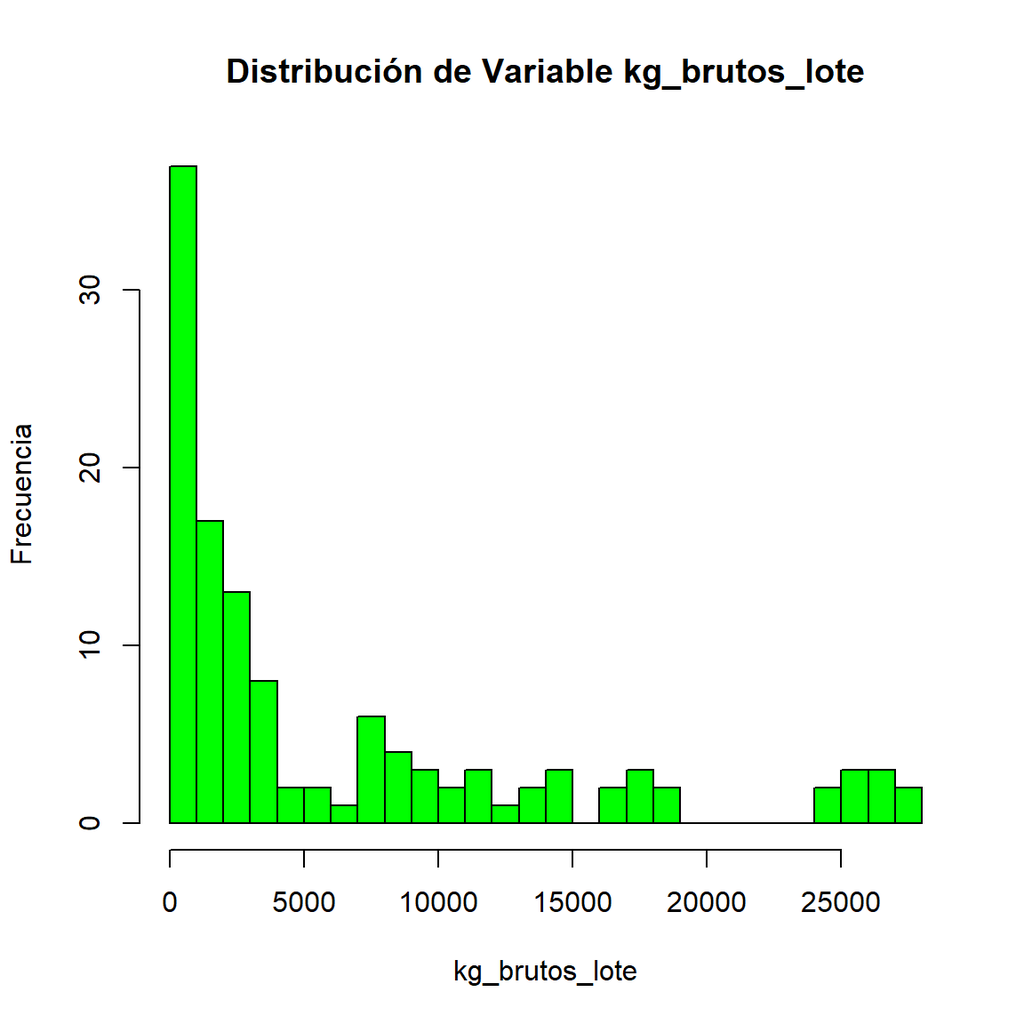

```r
# Histograma para la variable numérica kg_brutos_lote
hist(reporte$kg_brutos_lote, main="Distribución de Variable kg_brutos_lote", xlab="kg_brutos_lote", ylab="Frecuencia", col="green", breaks=30)
```

**Interpretación**: El histograma muestra la distribución de los kilogramos brutos por lote de paltas Hass. Observamos que la mayoría de los lotes tienen un peso bruto bajo, con un pico significativo en el rango más bajo de la escala (50 kg aproximadamente). La frecuencia disminuye rápidamente a medida que aumenta la cantidad de kg brutos por lote, indicando que hay menos lotes con pesos mayores. La distribución es asimétrica a la derecha, con algunos lotes que llegan hasta aproximadamente 27,291 kg, lo cual es coherente con los valores extremos observados. La forma de la distribución sugiere que la producción de paltas por lote es predominantemente de baja a media, con unos pocos lotes de producción alta.

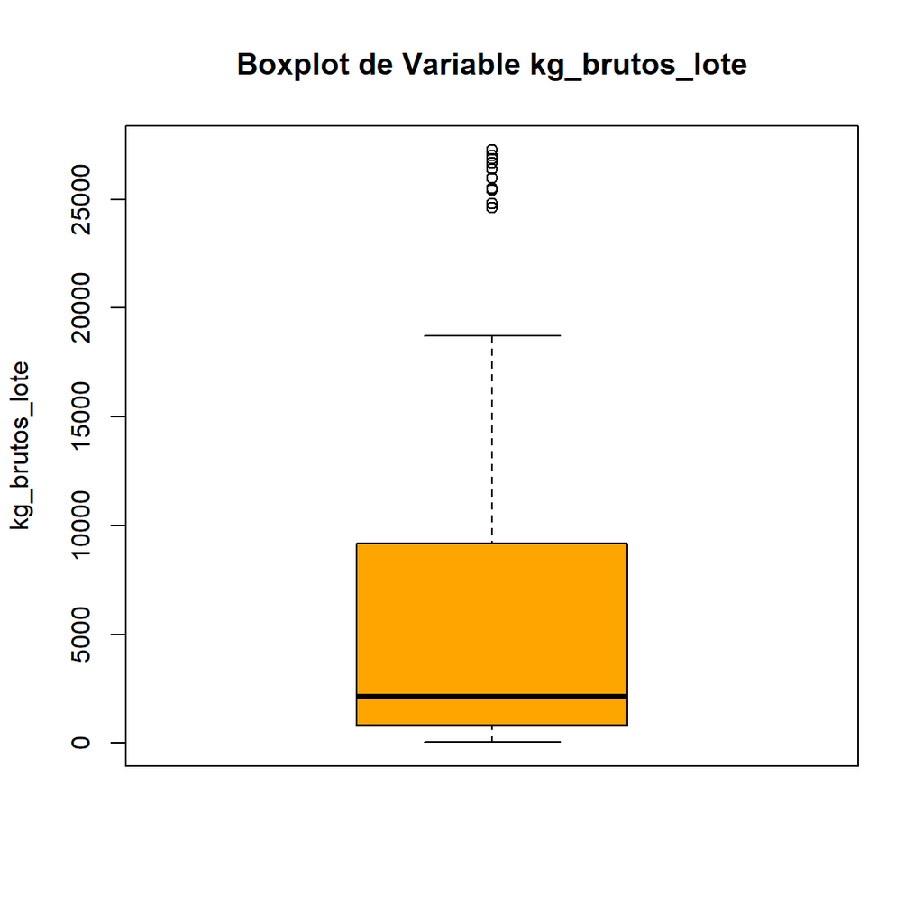

```r
# Boxplot para la variable numérica kg_brutos_lote
boxplot(reporte$kg_brutos_lote, main="Boxplot de Variable kg_brutos_lote", ylab="kg_brutos_lote", col="orange")
```

##### 4.2.2.2.3. Variable kg_exportados

Se obtienen los datos descriptivos más reperesentativos de la variable.

```r
# Datos descriptivos de la variable
summary(reporte$kg_exportados)
```

```
##    Min. 1st Qu.  Median    Mean 3rd Qu.    Max.
##     0.0   807.7  2046.2  5806.9  8581.9 24488.9
```

Se continua con la generación de gráficos.

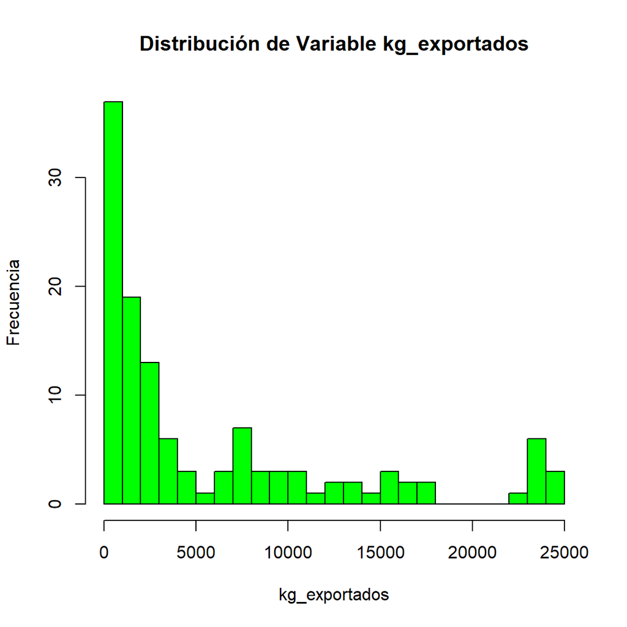

```r
# Histograma para la variable numérica kg_exportados
hist(reporte$kg_exportados, main="Distribución de Variable kg_exportados", xlab="kg_exportados", ylab="Frecuencia", col="green", breaks=30)
```

**Interpretación**: Observamos que la mayoría de los datos se concentran en el extremo inferior de la escala, con un número significativo de lotes que tienen pocos kilogramos exportados. Esto se refleja en la alta barra cerca del cero y sugiere que hay una gran cantidad de lotes con volúmenes de exportación bajos. La distribución se extiende hacia la derecha con una larga cola, indicando que hay menos lotes con volúmenes de exportación altos. Esta distribución asimétrica a la derecha sugiere que, aunque la mayoría de los lotes exporta una cantidad menor, hay algunos lotes que exportan cantidades mucho mayores, lo cual puede indicar la presencia de operaciones de exportación de mayor escala o eventos puntuales de exportación masiva.

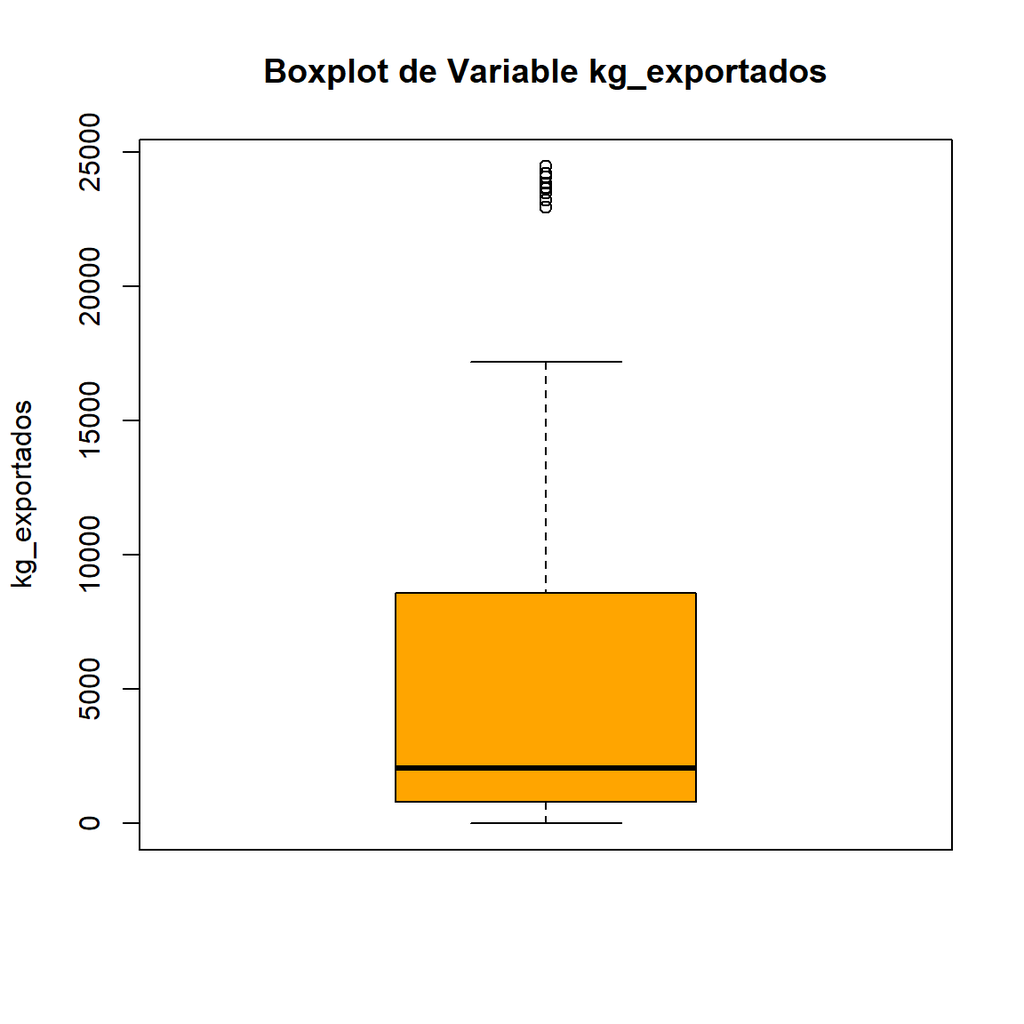

```r
# Boxplot para la variable numérica kg_exportados
boxplot(reporte$kg_exportados, main="Boxplot de Variable kg_exportados", ylab="kg_exportados", col="orange")
```

**Interpretación**: El boxplot proporciona un resumen visual de los kilogramos de paltas exportados. La línea dentro de la caja, que representa la mediana, está en 2046.2 kg, lo que indica que la mitad de los lotes exporta menos que esta cantidad y la otra mitad, más. El rango intercuartílico se extiende desde aproximadamente 808 hasta 8582 kg, mostrando la variabilidad de los datos. Notamos que hay varios puntos fuera del bigote superior, lo que indica la presencia de valores atípicos. Esto puede significar que algunos lotes tienen volúmenes de exportación significativamente más altos que la mayoría de los otros lotes. La presencia de estos valores atípicos puede tener un impacto en la media, que es de 5806.9 kg, haciéndola más alta que la mediana.

##### 4.2.2.2.4. Variable kg_exportados_hectarea

Se obtienen los datos descriptivos más reperesentativos de la variable.

```r
# Datos descriptivos de la variable
summary(reporte$kg_exportados_hectarea)
```

```
##    Min. 1st Qu.  Median    Mean 3rd Qu.    Max.
##    0.00   46.04  192.18  440.45  647.45 2244.27
```

Se continua con la generación de gráficos.

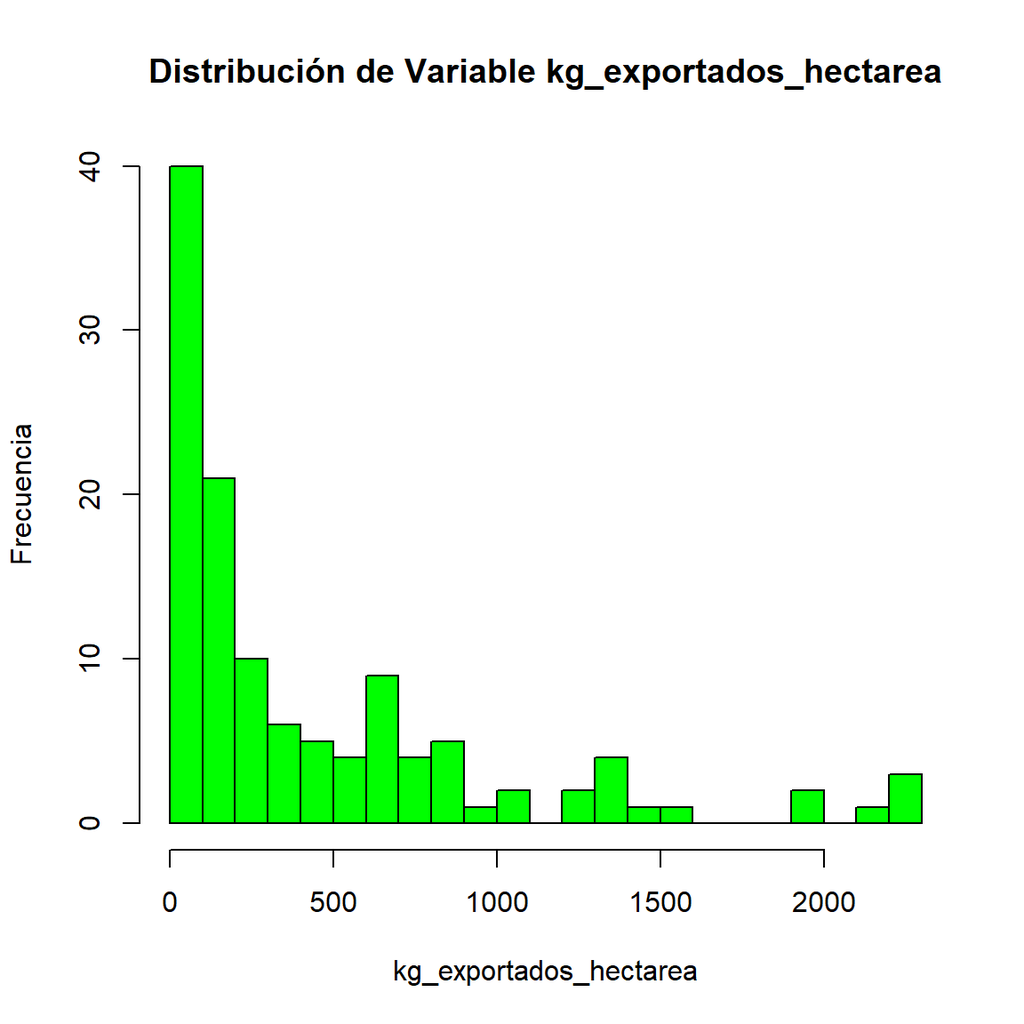

```r
# Histograma para la variable numérica kg_exportados_hectarea
hist(reporte$kg_exportados_hectarea, main="Distribución de Variable kg_exportados_hectarea", xlab="kg_exportados_hectarea", ylab="Frecuencia", col="green", breaks=30)
```

**Interpretación**: El histograma de los kilogramos exportados por hectárea muestra una clara concentración de valores en el extremo inferior del eje x. Con la mayoría de los datos agrupados cerca del origen, hay una fuerte asimetría hacia la derecha, indicando que hay menos parcelas con valores altos de exportación por hectárea. La barra más alta está cerca del cero, lo que podría sugerir que hay una cantidad considerable de hectáreas con muy bajos niveles de exportación. Esto puede reflejar limitaciones en la productividad o problemas en ciertas áreas que están afectando la capacidad de exportación.

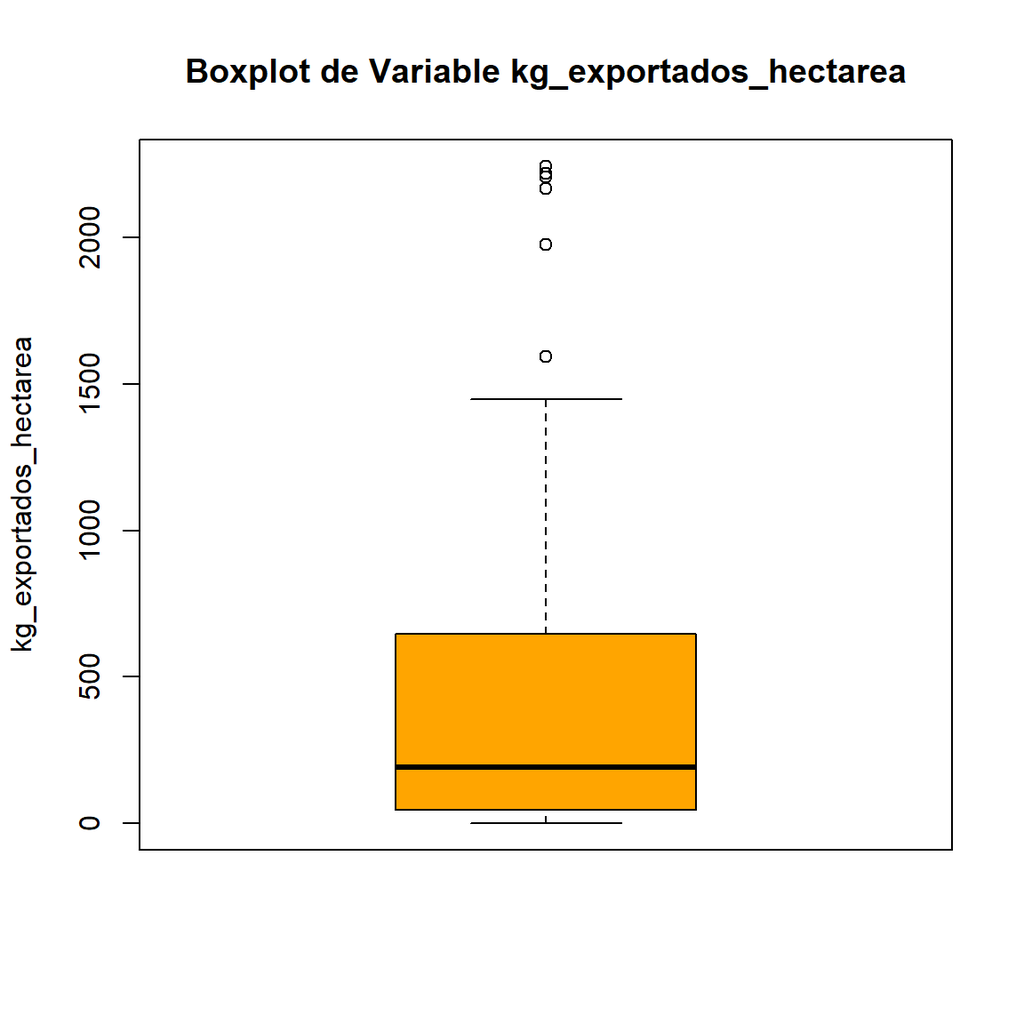

```r
# Boxplot para la variable numérica kg_exportados_hectarea
boxplot(reporte$kg_exportados_hectarea, main="Boxplot de Variable kg_exportados_hectarea", ylab="kg_exportados_hectarea", col="orange")
```

**Interpretación**: El boxplot para los kilogramos exportados por hectárea muestra una mediana de 192.18 kg por hectárea, lo que indica que la mitad de las hectáreas tienen un rendimiento de exportación por debajo de esta cifra y la otra mitad por encima. El rango intercuartílico se extiende desde aproximadamente 46 a 647 kg por hectárea, lo que sugiere que hay una variación moderada en los rendimientos de exportación entre la mayoría de las hectáreas. La presencia de varios valores atípicos indica que hay algunas hectáreas con rendimientos excepcionalmente altos, mucho más allá del promedio. La media es de 440.45 kg por hectárea, esto podría estar influenciado por estos valores atípicos, y es más alta que la mediana, lo que sugiere una distribución sesgada.

##### 4.2.2.2.5. Variable temperatura_promedio

Se obtienen los datos descriptivos más representativos de la variable.

```r
# Datos descriptivos de la variable
summary(reporte$temperatura_promedio)
```

```
##    Min. 1st Qu.  Median    Mean 3rd Qu.    Max.
##   20.56   22.90   23.63   23.34   24.28   25.20
```

Se continua con la generación de gráficos.

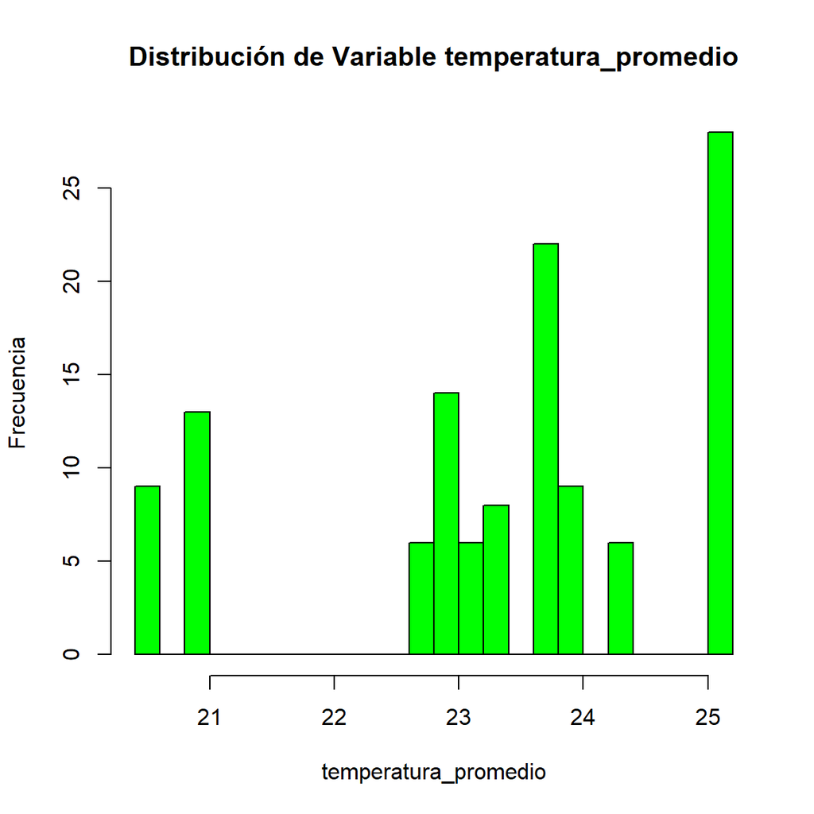

```r
# Histograma para la variable numérica temperatura_promedio
hist(reporte$temperatura_promedio, main="Distribución de Variable temperatura_promedio", xlab="temperatura_promedio", ylab="Frecuencia", col="green", breaks=30)
```

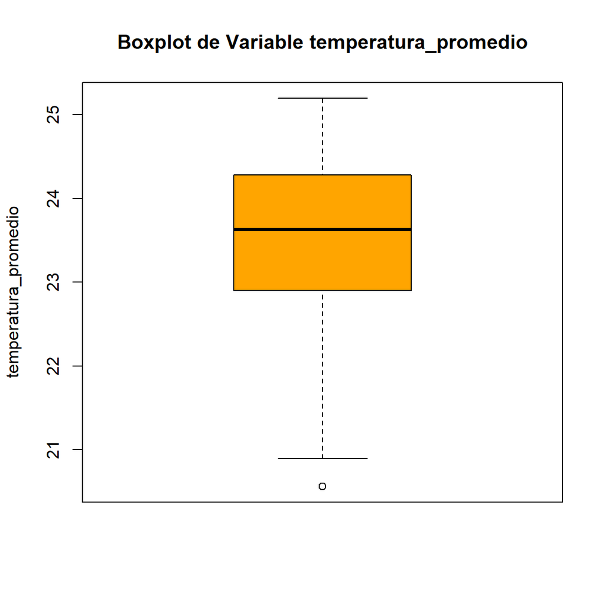

```r
# Boxplot para la variable numérica temperatura_promedio
boxplot(reporte$temperatura_promedio, main="Boxplot de Variable temperatura_promedio", ylab="temperatura_promedio", col="orange")
```

##### 4.2.2.2.6. Variable temperatura_maxima

Se obtienen los datos descriptivos más reperesentativos de la variable.

```r
# Datos descriptivos de la variable
summary(reporte$temperatura_maxima)
```

```
##    Min. 1st Qu.  Median    Mean 3rd Qu.    Max.
##   26.10   30.50   32.00   31.38   32.80   34.20
```

Se continua con la generación de gráficos.

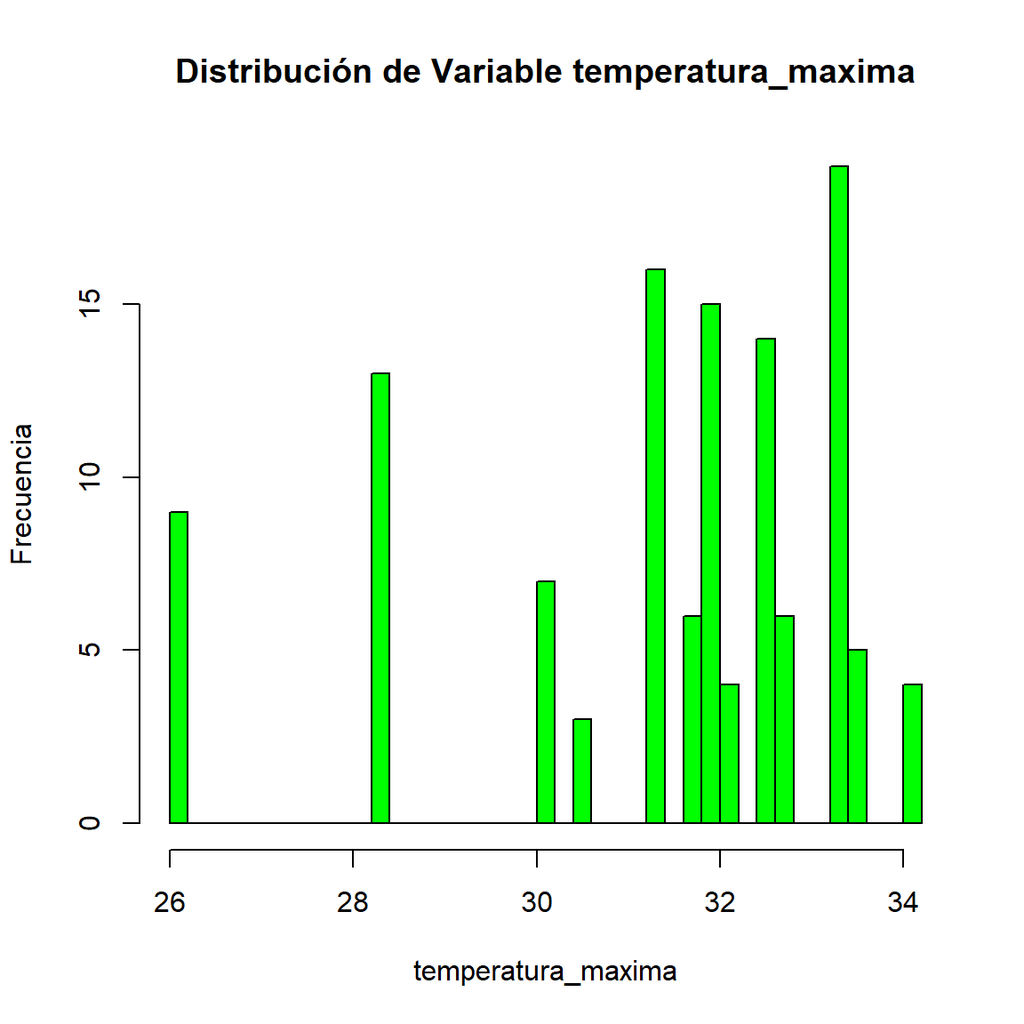

```r
# Histograma para la variable numérica temperatura_maxima
hist(reporte$temperatura_maxima, main="Distribución de Variable temperatura_maxima", xlab="temperatura_maxima", ylab="Frecuencia", col="green", breaks=30)
```

**Interpretación**: El histograma de la variable muestra una distribución de frecuencias con múltiples modas, reflejando posiblemente diferentes grupos o condiciones que afectan las temperaturas máximas. Las temperaturas parecen agruparse alrededor de varios rangos, con picos notables alrededor de los valores de 28°C, 32°C y 34°C, lo que podría indicar variaciones estacionales o microclimas dentro de las áreas de cultivo.

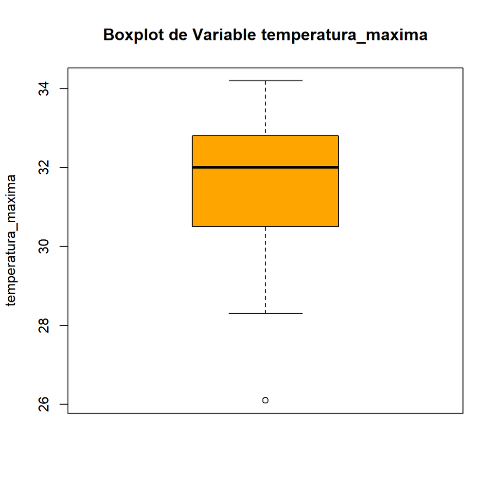

```r
# Boxplot para la variable numérica temperatura_maxima
boxplot(reporte$temperatura_maxima, main="Boxplot de Variable temperatura_maxima", ylab="temperatura_maxima", col="orange")
```